# Cuestionario 2 · GLM Binomial y Poisson

Bioestadística · Semana 2 · 2026-II

Autor/a

[Javier Rodríguez-Barrios](https://www.unimagdalena.edu.co/)

Fecha de publicación

4 de octubre de 2026

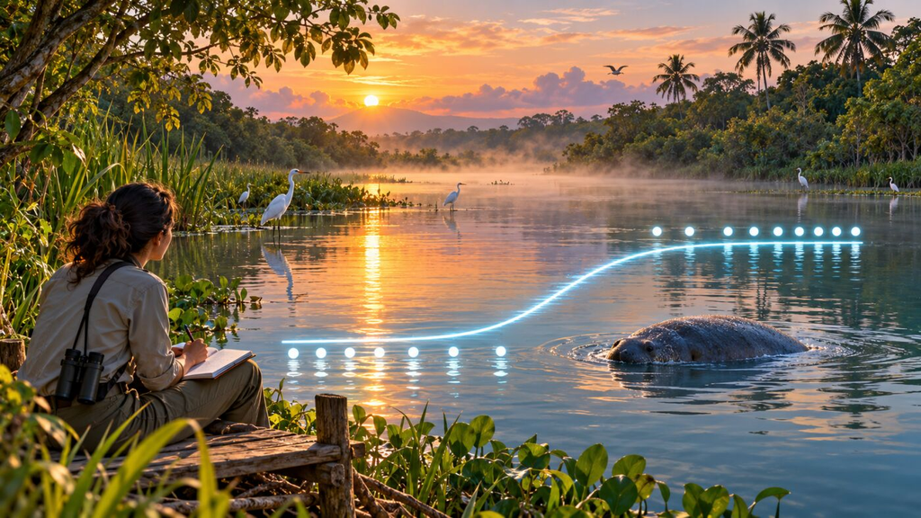

**NotaCómo usar este cuestionario**

Ejercicio aplicado (RA1, RA2) que se resuelve después del `Taller · GLM Binomial y Poisson en R` y de la práctica de opción múltiple (Cuestionario 1). Los escenarios **no son los mismos** del taller: usan otros datos, para razonar el resultado en lugar de recordarlo.

**ImportanteRuta mínima calificable (45 pts · rúbrica R1)**

| Bloque | Qué se entrega | Criterio de R1 |
| --- | --- | --- |
| **A — Conceptos** | **Bloque completo** (A1 a A5) | 1. Razonamiento y elección (20) · 2. Ejecución e interpretación (15) |
| **B o C — Casos aplicados** | **Uno de los dos bloques, completo** (B: binomial, Rhodophyta; C: Poisson, bentos) | 1. Razonamiento y elección · 2. Ejecución e interpretación |
| **D — ¿Qué familia se usa?** | **Bloque completo** (D1 a D4) | 1. Razonamiento y elección |
| **E — Proyecto de grado** | **E1 y E2** (obligatorias) | 3. Proyecto propio (10) |

- Al inicio de la entrega se indica si se eligió el Bloque B o el C. Si no se indica, se califica el primero que aparezca resuelto.
- El bloque no elegido queda como práctica: no suma ni resta.
- Se entrega en Moodle el `.qmd` con la ruta mínima resuelta y su render (HTML o PDF). Cierra el **jueves 22 de octubre, 23:59**. La tarea se habilita al completar la práctica de opción múltiple (Cuestionario 1).

Las respuestas no se incluyen en esta versión: se discuten en clase después del cierre de la entrega.

## Bloque A — Conceptos

**Tip**

**Ruta mínima:** responder **todo el Bloque A** (A1 a A5).

**A1.** ¿Por qué no basta con ajustar `lm()` a una variable de presencia/ausencia (0/1)? Mencionar un problema concreto de las predicciones.

**A2.** En un GLM, ¿sobre qué actúa la función de enlace: sobre cada observación de Y (como una transformación clásica) o sobre otra cosa? Explicar la diferencia y una ventaja práctica cuando hay ceros.

**A3.** Un colega reporta un GLM binomial con β = 0.10 y afirma que “el efecto es pequeño”. ¿Qué falta antes de que esa afirmación tenga sentido?

**A4.** ¿Qué mide φ (phi) en un GLM Poisson, cómo se calcula y qué decisión se tomaría si φ = 3.5?

**A5.** Un GLM binomial arroja p = 0.003 para el predictor, pero la devianza solo se reduce un 8 %. ¿Es contradictorio? Explicar.

## Bloque B — Ocupación de macroalgas Rhodophyta y profundidad

**Tip**

**Ruta mínima:** resolver **uno** de los Bloques B o C, completo.

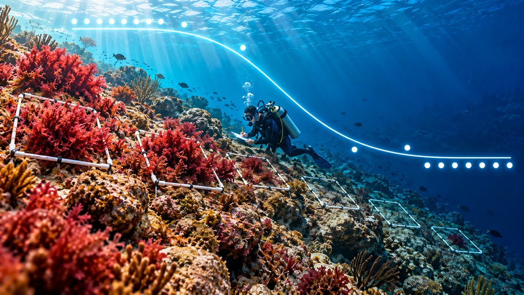

Una estudiante registra la presencia/ausencia de un banco de Rhodophyta en 50 cuadrantes a distinta profundidad y ajusta un GLM binomial:

| Coeficiente | Estimado | OR = exp(β) | IC 95 % (OR) | Valor p |
| --- | --- | --- | --- | --- |
| Intercepto | 1.645 | — | — | 0.009 |
| Profundidad (m) | −0.154 | 0.857 | [0.760, 0.952] | 0.007 |

n = 50 cuadrantes, 27 ocupados.

**B1.** Escribir la ecuación logit del modelo e interpretar el signo del coeficiente de profundidad en términos biológicos (pista: disponibilidad de luz).

**B2.** El IC del OR es [0.760, 0.952] y no incluye 1. ¿Qué indica sobre la relación entre profundidad y ocupación?

**B3.** Calcular la probabilidad de ocupación predicha a 5 m y a 15 m de profundidad (con la ecuación logit y `plogis()`, o a mano).

**B4.** Si OR = 0.857 significa que “por cada metro adicional, los odds de ocupación se multiplican por 0.857”, ¿por qué NO es correcto afirmar que “la ocupación baja un 14.3 % por metro”? (pista: diferencia entre *odds* y *probabilidad*).

## Bloque C — Abundancia bentónica y perturbación antrópica

**Tip**

**Ruta mínima:** resolver **uno** de los Bloques B o C, completo.

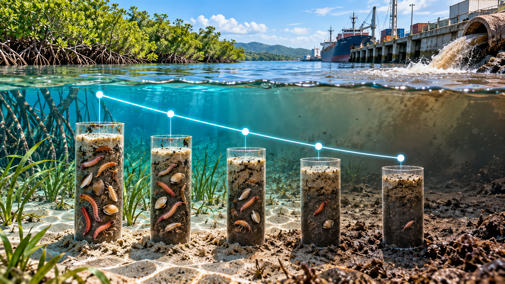

Un estudiante cuenta organismos bentónicos por núcleo de sedimento en 34 estaciones con distinto nivel de perturbación antrópica (índice 0–10) y ajusta un GLM Poisson:

| Coeficiente | Estimado | Razón de tasas | Valor p |
| --- | --- | --- | --- |
| Intercepto | 2.146 | — | < 0.001 |
| Perturbación | −0.056 | 0.946 | 0.013 |

n = 34, φ = 1.56, AIC = 176.0

**C1.** Interpretar la razón de tasas (0.946) en una frase, en el contexto de perturbación antrópica y comunidades bentónicas.

**C2.** φ = 1.56 está dentro de la zona de alerta vista en clase (φ ≈ 1: equidispersión; φ > 1.2–2: sobredispersión), aunque lejos del ejemplo del arrecife en el taller (φ = 2.22). ¿Se mantendría el Poisson o se corregiría? Justificar.

**C3.** Si se ajustara `MASS::glm.nb()` en lugar de `glm(family = poisson)`, ¿se esperaría que el coeficiente de perturbación cambie mucho? ¿Qué sí se esperaría que cambie?

## Bloque D — ¿Qué familia se usa?

**Tip**

**Ruta mínima:** responder **todo el Bloque D** (D1 a D4).

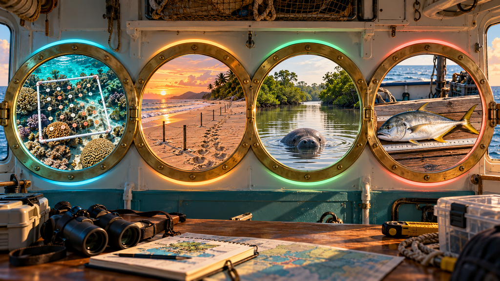

Para cada situación, indicar familia GLM, función de enlace y cualquier detalle adicional del modelo:

**D1.** Proporción de cobertura de coral vivo por cuadrante, medida como puntos con coral / total de puntos muestreados.

**D2.** Número de nidos de tortuga marina por temporada en segmentos de playa de longitud distinta.

**D3.** Presencia/ausencia de manatí antillano en estaciones de monitoreo de un río.

**D4.** Longitud total (cm) de individuos de jurel capturados en un muestreo pesquero.

## Bloque E — Proyecto de grado

**Tip**

**Ruta mínima:** **E1 y E2 son obligatorias**. Se califican con el criterio 3 de la rúbrica R1 (10 pts).

**E1.** Describir en una frase una variable respuesta del propio proyecto de grado que requeriría un GLM (y no `lm()`). Indicar familia y enlace.

**E2.** Si esa variable es un conteo, ¿qué proceso biológico del sistema podría generar sobredispersión (agregación, parches, exceso de ceros)? ¿El esfuerzo de muestreo es igual entre unidades o requeriría offset?

## Referencias

- Quinn, G. P., & Keough, M. J. (2024). *Experimental Design and Data Analysis for Biologists* (2nd ed.). Cambridge University Press. [enlace_ejercicios](https://mjkeough.github.io/examples.html)
- Logan, M. (2011). *Biostatistical Design and Analysis Using R*. Wiley-Blackwell. [enlace_ejercicios](https://bcs.wiley.com/he-bcs/Books?action=index&bcsId=5684&itemId=1405190086); [enlace_libro](https://onlinelibrary.wiley.com/doi/book/10.1002/9781444319620)

**Nota**

Los escenarios de este cuestionario son de elaboración propia; sus cifras se reproducen con datos simulados en R (script de respaldo del docente) y no reproducen ejercicios de las fuentes citadas.